# Machine Learning Project

S. Rich

May 7, 2016

Github Repo: https://github.com/richelm/practicalmachinelearning

## Data Exploration

With a view of the data many variables clearly had near zero variance. The caret function nearZeroVar quickly eliminated those. Others like “X”, “user_name”, and “timestamp” variables too were not necessary. What we ended up with was the accelerometer data for each of the four accelerometers; belt, arm, dumbbell, and forearm.

```r
# read data from file
trainingData <- read.table("./data/pml-training.csv", sep=",", na.strings = c("NA","#DIV/0!"),header = TRUE)
testingData <- read.table("./data/pml-testing.csv", sep=",", na.strings = c("NA","#DIV/0!"),header = TRUE)

# clean data
trainingData <- trainingData[,-grep( "timestamp|X|user_name|num_window" , names(trainingData))]
trainingData[is.na(trainingData)] <- 0
nzv <- nearZeroVar(trainingData)
trainingData <- trainingData[,-nzv]
```

## Models

All models use the 52 accelerometer related variables as predictors. These data are split into training and testing for our model building and accuracy testing. Three models were generated and compared; Random Forest, CART, and Stochastic Gradient Boosting (Boosting).

```r
set.seed(526)
inTrain <- createDataPartition(trainingData$classe, p=0.70, list=FALSE)
training <- trainingData[inTrain,]
testing <- trainingData[-inTrain,]
```

### Random Forest

Cross validation is inherit in the random forest model because at each split it considers only a subset of the predictors.

```r
rfFit <- randomForest(classe~., data = training)
rfPredict <- predict(rfFit, newdata = testing)
rfAccuracy <- confusionMatrix(data=rfPredict, testing$classe)$overall['Accuracy']
rfAccuracy
```

```
   Accuracy
  0.9935429
```

### CART

Both CART and Boosting models use k-fold cross validation approach with 5 folds.

```r
cartCtrl <- trainControl(method = "cv", number = 5, savePredictions = TRUE)
cartFit <- train(classe~., data = training, method = "rpart", trControl=cartCtrl)
cartPredict <- predict(cartFit, newdata = testing)
cartAccuracy <- confusionMatrix(data=cartPredict, testing$classe)$overall['Accuracy']
cartAccuracy
```

```
   Accuracy
  0.4944775
```

### Boosting

```r
gbmCtrl <- trainControl(method = "cv", number = 5, savePredictions = TRUE)
gbmFit <- train(classe~., data = training, method = "gbm", trControl=gbmCtrl, verbose=FALSE)
gbmPredict <- predict(gbmFit, newdata = testing)
gbmAccuracy <- confusionMatrix(data=gbmPredict, testing$classe)$overall['Accuracy']
gbmAccuracy
```

```
  Accuracy
  0.959898
```

### Model Summary

```r
msr1 <- c(100*round(rfAccuracy,3),100*(round((1 - rfAccuracy),3)))
msr2 <- c(100*round(cartAccuracy,3),100*(round((1 - cartAccuracy),3)))
msr3 <- c(100*round(gbmAccuracy,3),100*(round((1 - gbmAccuracy),3)))
ms <- as.data.frame(rbind(msr1, msr2, msr3))
rownames(ms) <- c("Random Forest","CART","Boosting")
colnames(ms) <- c("Overall Accuracy %","Overall Error %")
ms
```

```
                Overall Accuracy % Overall Error %
  Random Forest               99.4             0.6
  CART                        49.4            50.6
  Boosting                    96.0             4.0
```

Random Forest model gives the best overall accuracy and error. Before choosing this as our final model we look in more detail. To do this we plot error vs number of trees and view the model details.

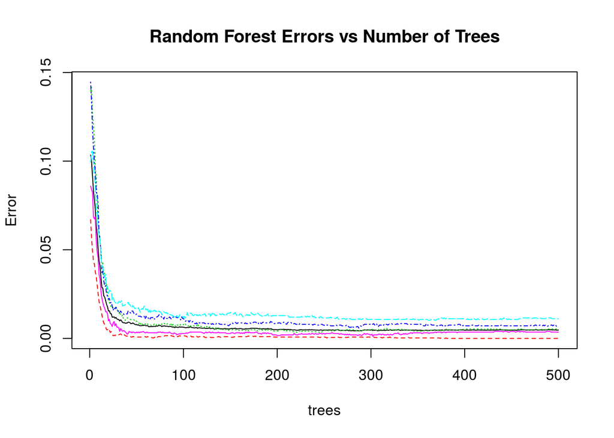

```r
plot(rfFit,main="Random Forest Errors vs Number of Trees")
```

```r
rfFit
```

```
  Call:
   randomForest(formula = classe ~ ., data = training)
                 Type of random forest: classification
                       Number of trees: 500
  No. of variables tried at each split: 7

          OOB estimate of  error rate: 0.47%
  Confusion matrix:
       A    B    C    D    E class.error
  A 3906    0    0    0    0 0.000000000
  B    9 2644    5    0    0 0.005267118
  C    0   13 2379    4    0 0.007095159
  D    0    0   24 2227    1 0.011101243
  E    0    0    2    7 2516 0.003564356
```

### Predict with Test Data

Based on the plot and details of the random forest model we use it to predict the quiz test data.

```r
quizPredict <- predict(rfFit, newdata = testingData)
quizPredict
```

```
   1  2  3  4  5  6  7  8  9 10 11 12 13 14 15 16 17 18 19 20
   B  A  B  A  A  E  D  B  A  A  B  C  B  A  E  E  A  B  B  B
  Levels: A B C D E
```